# MidtermPractice

### 4.2 Residual

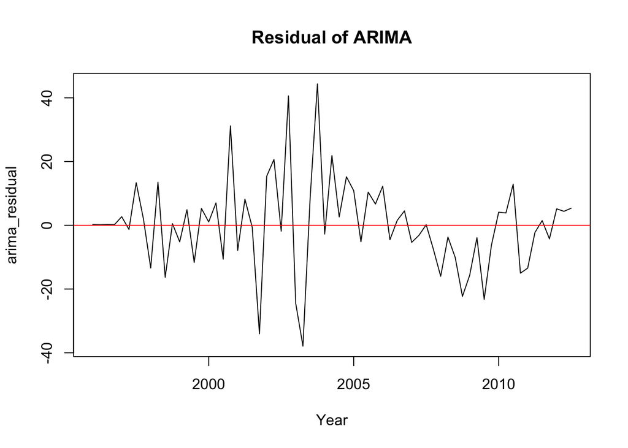

```r
arima_residual <- residuals(forecast_arima)
plot(arima_residual, main = "Residual of ARIMA", xlab = "Year")
abline(h=0, col="red")
```

> Your residuals fluctuate around 0, which indicates that the model does not systematically over- or under-predict. Residuals look like white noise: no visible trend or seasonality. There are a few big residual spikes, especially around2003-2004 and 2009-2010, possible unexpected events there.

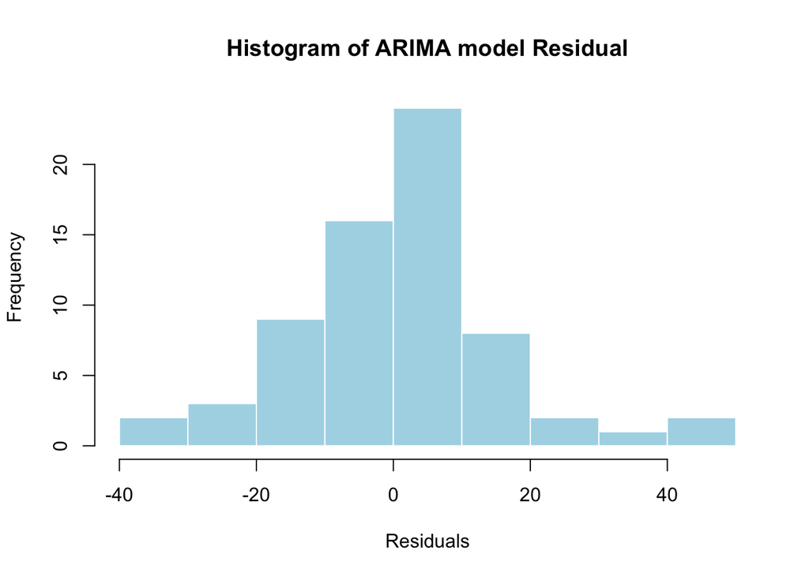

```r
hist(arima_residual, main = "Histogram of ARIMA model Residual", xlab="Residuals", col="lightblue", border="white")
```

> The shape is roughly centered around zero The distribution is fairly symmetric, although not perfectly. No extremely heavy tails or skewness.

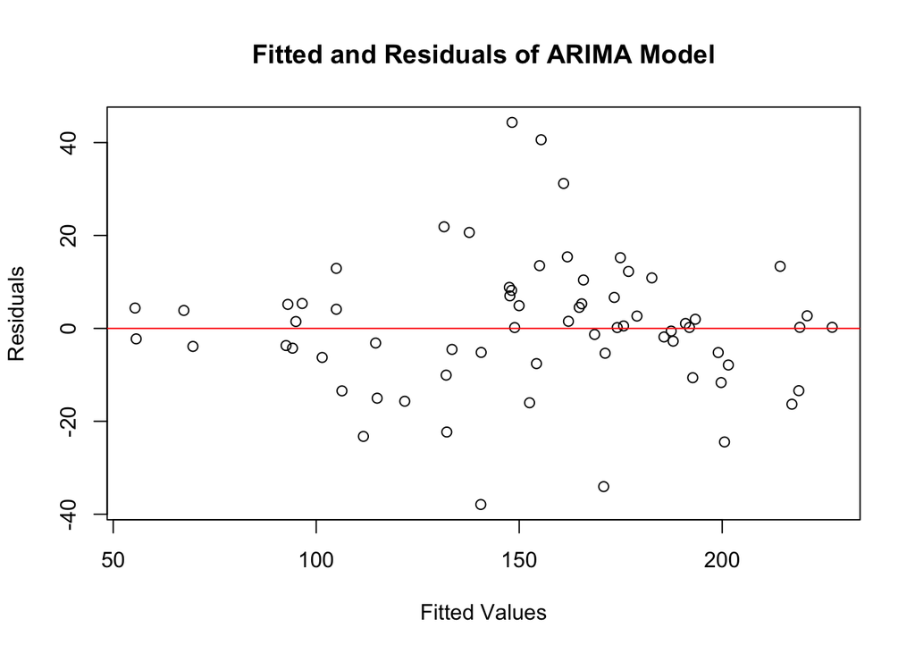

```r
plot(as.numeric(fitted(forecast_arima)), as.numeric(arima_residual),
     main = "Fitted and Residuals of ARIMA Model",
     xlab = "Fitted Values",
     ylab = "Residuals"
     )
abline(h=0, col= "red")
```

> No clear pattern centered around zero Constant variance A few larger residuals appear isolated, may represent short term shocks

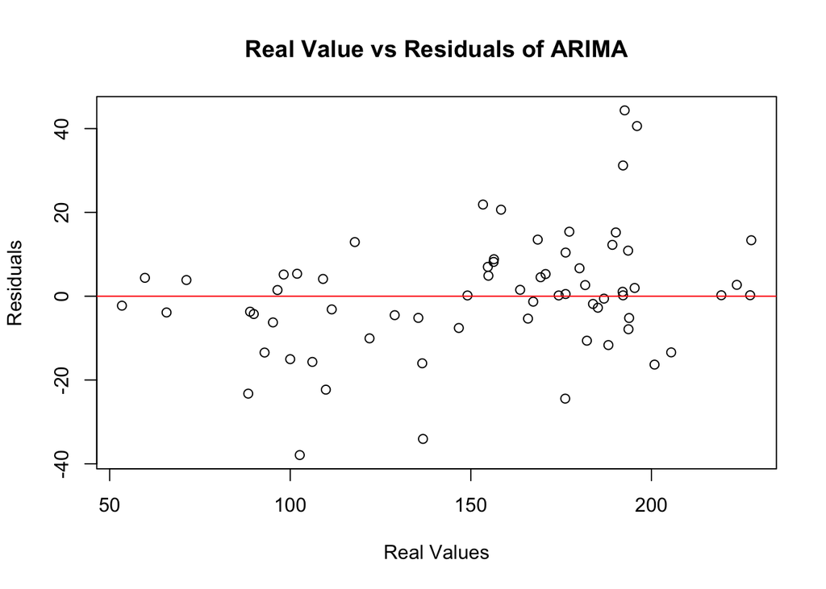

```r
plot(as.numeric(arrivals_ts), as.numeric(arima_residual),
     main = "Real Value vs Residuals of ARIMA",
     xlab = "Real Values",
     ylab = "Residuals"
     )

abline(h = 0, col= "red")
```

> Residuals randomly scattered around zero → model is unbiased No visible pattern or shape → residuals do not depend on actual values Variance is mostly stable across the range, though a few larger residuals appear near high values → acceptable for this dataset.

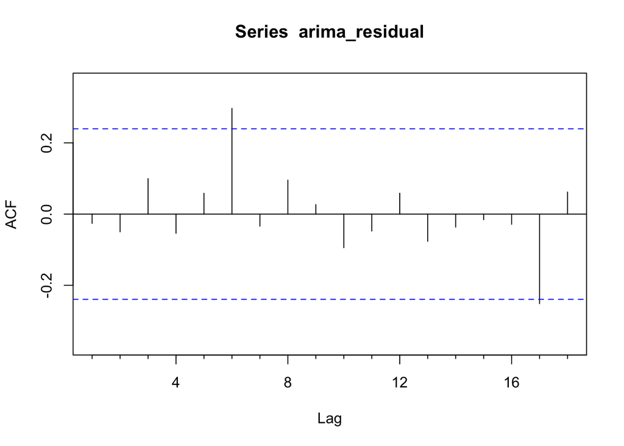

```r
Acf(arima_residual)
```

> Most spikes fall inside the bands, no significant remaining autocorrelation. There is two slightly pike at Lags 6 and 17, but they’re still close to the boundary No repeating seasonal pattern and no obvous structure So overall, the ACF suggests that the ARIMA model has done a reasonable job: the residuals look mostly random, meaning the model has captured the trend and short-term correlation in the data.

### 4.3 Accuracy& Summary

```r
accuracy(forecast_arima)
```

```
##                     ME     RMSE      MAE        MPE     MAPE     MASE
## Training set 0.2066998 14.23834 10.05495 -0.8712575 7.121926 0.648507
##                     ACF1
## Training set -0.02622596
```

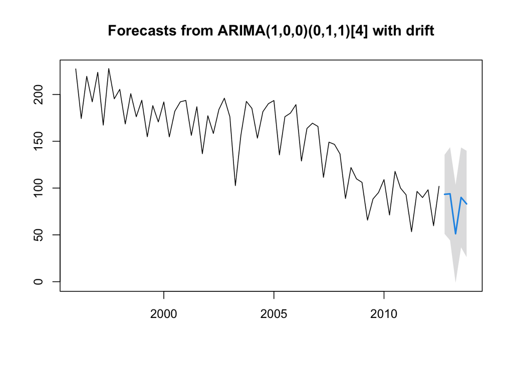

```r
plot(forecast_arima)
```

- ARIMA’s prediction error is about 7%, which is quite good for tourism forecasting. Anything below 10% is considered high accuracy.